# prosperLoanData Exploration

## by Mohamed Adel

## Preliminary Wrangling

> This data set contains 113,937 loans with 81 variables on each loan, including loan amount, borrower rate (or interest rate), current loan status, borrower income, and many others.

### What is/are the main feature(s) of interest in your dataset?

I'm most interested in figuring out what features are best for predicting the proposer loans rate of success in the dataset.

### What features in the dataset do you think will help support your investigation into your feature(s) of interest?

I expect that borrower APR will have the strongest effect on each rate of success proposer loans: the length of the loan expressed in months (term) ,The Borrower's interest rate for this loan (BorrowerRate) ,LoanOriginalAmount .

## Univariate Exploration

I'll start by looking at the distribution of the main variable of interest: the proposer loans rate of success.

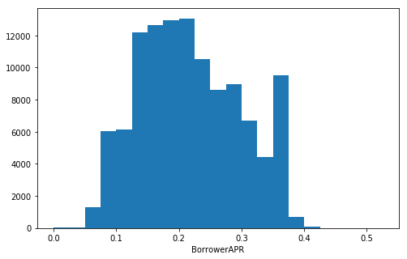

```python
binsize = 0.025
bins = np.arange(0, PLD['BorrowerAPR'].max()+binsize, binsize)

plt.figure(figsize=[8, 5])
plt.hist(data = PLD, x = 'BorrowerAPR', bins = bins)
plt.xlabel('BorrowerAPR')
plt.show()
```

the maximam APR rate are between 0.2 more or less

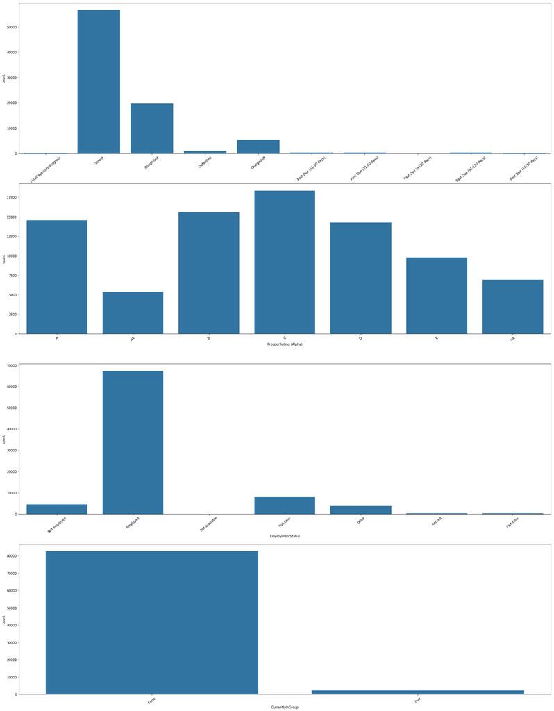

```python
# let's plot all three together to get an idea of each ordinal variable's distribution.

fig, ax = plt.subplots(nrows=4, figsize = [30,40])

default_color = sb.color_palette()[0]


sb.countplot(data = PLD, x = 'LoanStatus', color = default_color, ax = ax[0] )
#plt.xticks(rotation=50)
sb.countplot(data = PLD, x = 'ProsperRating (Alpha)', color = default_color, ax = ax[1])
sb.countplot(data = PLD, x = 'EmploymentStatus', color = default_color, ax = ax[2])
sb.countplot(data = PLD, x = 'CurrentlyInGroup', color = default_color, ax = ax[3])

for ax in fig.axes:
    plt.sca(ax)
    plt.xticks(rotation=40)
plt.show()
```

tips:

1. most of loans are currently paid or n un compiletly paid
2. Interestingly enough ratings are almost normally distributed with the highest AA rating and the lowest rating HR are the least common and average rating C being the most common
3. most loan carriyers (borrower) are employed
4. most loan carriyers (borrower) are not in group

```python
sb.countplot(data=PLD, x='ListingCategory (numeric)', color=default_color)
```

[figure not shown]

The category of the listing that the borrower selected when posting their listing: 0 - Not Available, 1 - Debt Consolidation, 2 - Home Improvement, 3 - Business, 4 - Personal Loan, 5 - Student Use, 6 - Auto, 7- Other, 8 - Baby&Adoption, 9 - Boat, 10 - Cosmetic Procedure, 11 - Engagement Ring, 12 - Green Loans, 13 - Household Expenses, 14 - Large Purchases, 15 - Medical/Dental, 16 - Motorcycle, 17 - RV, 18 - Taxes, 19 - Vacation, 20 - Wedding Loans

```python
sb.countplot(data=PLD, x='Recommendations', color=default_color);
```

[figure not shown]

Overwhelming majority of loans obtained without recomendations.

### Discuss the distribution(s) of your variable(s) of interest. Were there any unusual points? Did you need to perform any transformations?

> Prosper ratings are almost normally distributed.ProsperScore are normally distributed .The distribution of borrowers APR looks multimodal. Most of the values are at the range of 0.05 and 0.4. There are no unusual points and no need to perform any transformations.

### Of the features you investigated, were there any unusual distributions? Did you perform any operations on the data to tidy, adjust, or change the form of the data? If so, why did you do this?

```python
# plot matrix of numeric features against categorical features.
# can use a larger sample since there are fewer plots and they're simpler in nature.

samples = np.random.choice(PLD.shape[0], 2000, replace = False)
PLD_samp = PLD.loc[samples,:]

def boxgrid(x, y, **kwargs):
    """ Quick hack for creating box plots with seaborn's PairGrid. """
    default_color = sb.color_palette()[0]
    sb.boxplot(x, y, color = default_color)

plt.figure(figsize = [10, 10])
g = sb.PairGrid(data = PLD_samp, y_vars = numeric_vars , x_vars = categoric_vars,
                size = 3, aspect = 1.5)
g.map(boxgrid)
plt.show();
```

[figure not shown]

The figure shows that the loan amount is increased with the increase of loan term. The borrower APR decreases with the better rating. Borrowers with the best Prosper ratings have the lowest APR. It means that the Prosper rating has a strong effect on borrower APR. Borrowers with better rating also have larger monthly income and loan amount. Employed, self-employed and full time borrowers have more monthly income and loan amount than part-time, retired and not employed borrowers.

```python
# since there's only three subplots to create, using the full data should be fine.
plt.figure(figsize = [15, 15])
x =['LoanStatus','ProsperRating (Alpha)','EmploymentStatus' ,'ProsperRating (Alpha)','IsBorrowerHomeowner','CurrentlyInGroup']
# subplot 1: LoanStatus vs EmploymentStatus
plt.subplot(4, 1, 1)
sb.countplot(data = PLD, x = 'EmploymentStatus', hue = 'LoanStatus', palette = 'Blues')

# subplot 2: LoanStatus vs. ProsperRating (Alpha)
ax = plt.subplot(4, 1, 2)
sb.countplot(data = PLD, x = 'ProsperRating (Alpha)', hue = 'LoanStatus', palette = 'Blues')
ax.legend(ncol = 1) # re-arrange legend to reduce overlapping

# subplot 3: EmploymentStatus vs. IsBorrowerHomeowner, use different color palette
ax = plt.subplot(4, 1, 3)
sb.countplot(data = PLD, x = 'EmploymentStatus', hue = 'IsBorrowerHomeowner', palette = 'Greens')
ax.legend(loc = 1, ncol = 1) # re-arrange legend to remove overlapping

# subplot 1: LoanStatus vs EmploymentStatus
plt.subplot(4, 1, 4)
sb.countplot(data = PLD, x = 'CurrentlyInGroup', hue = 'LoanStatus', palette = 'Blues')

plt.show()
```

[figure not shown]

most loaonstatus as current are for employed ones , has a 'c' rate for porsperRating (ALpha) and that employed ones most of them owend their iwen homes and not currently in group

### Talk about some of the relationships you observed in this part of the investigation. How did the feature(s) of interest vary with other features in the dataset?

> The APR of the borrower is negatively correlated with the original amount of the loan, which means that the larger the amount of the loan, the lower the APR. It also indicates that the APR has a wide range at the different size of the loan amount, but with the rise in the loan amount, the range of APR decreases. The rating of Prosper also has a clear influence on the APR of the applicant, which decreases with the better rating.

### Did you observe any interesting relationships between the other features (not the main feature(s) of interest)?

> The original amount of the loan is positively associated with the monthly income reported, because borrowers with more monthly income might lend more money, it makes sense. It also illustrates that better-rated borrowers also have greater monthly income and loan amounts. There is a relationship between a performance rating and a term. Proportionally, on B and C ratings, there are more 60-month loans. There are just 36 months of loans for borrowers with HR ratings.

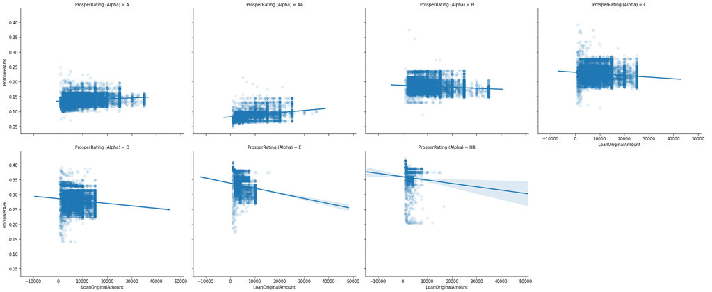

```python
# Prosper rating effect on relationship of APR and loan amount
H=sb.FacetGrid(data=PLD, aspect=1.2, height=5, col='ProsperRating (Alpha)', col_wrap=4)
H.map(sb.regplot, 'LoanOriginalAmount', 'BorrowerAPR', x_jitter=0.04, scatter_kws={'alpha':0.1});
H.add_legend();
```

With prosper rating, the loan sum and borrower APR have a negative relationship and turns marginally to likely as prosperRating is lifted from HR to A or better. This could be because individuals with A or AA ratings want to borrow more cash, raising APR that may deter them from borrowing any further and optimising benefit. But lower-rated individuals prefer to borrow less money, and a decrease in APR might allow them to borrow more.

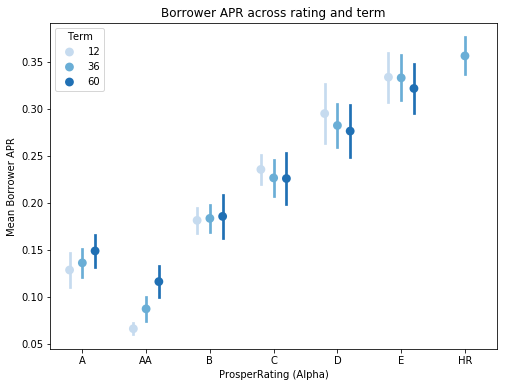

```python
fig = plt.figure(figsize = [8,6])
ax = sb.pointplot(data = PLD, x = 'ProsperRating (Alpha)', y = 'BorrowerAPR', hue = 'Term',
           palette = 'Blues', linestyles = '', dodge = 0.4, ci='sd')
plt.title('Borrower APR across rating and term')
plt.ylabel('Mean Borrower APR')
ax.set_yticklabels([],minor = True);
```

Interestingly, the borrower APR decrease with the increase of borrow term for people with HR-C raings. But for people with B-AA ratings, the APR increase with the increase of borrow term.

```python
fig, ax = plt.subplots(ncols=2, figsize=[12,6])
sb.pointplot(data = PLD, x = 'ProsperRating (Alpha)', y = 'StatedMonthlyIncome', hue = 'Term',
           palette = 'Greens', linestyles = '', dodge = 0.4, ax=ax[0])
sb.pointplot(data = PLD, x = 'ProsperRating (Alpha)', y = 'LoanOriginalAmount', hue = 'Term',
           palette = 'Purples', linestyles = '', dodge = 0.4, ax=ax[1]);
```

[figure not shown]

> there is a interaction between term and rating. We will see that with better Prosper rating, the loan amount of all three terms increases, the amplitude of loan amount between terms also becomes larger and it is increasing. it doesn't seem like there is a interaction effect between term and rating, the consequences of term is similar among different ratings.

### Talk about some of the relationships you observed in this part of the investigation. Were there features that strengthened each other in terms of looking at your feature(s) of interest?

> I make my exploration analysis of borrower APR against loan amount by looking at the impact of the Prosper rating. The multivariate exploration showed that the relationship between borrower APR and loan amount turns from negative to slightly positive when the Prosper ratings increased from HR to AA I ,then i visualize the rating and term effects on loan amount, it is showing that if you have good Prosper rating, the loan amount of all three terms will be increase

### Were there any interesting or surprising interactions between features?

> there were a surprising interaction is that the borrower APR and loan amount is negatively correlated when the Prosper ratings are from HR to B, but the correlation is turned to be positive when the ratings are A and AA. Another interesting thing is that the borrower APR decrease with the increase of borrow term for people with HR-C raings. But for people with B-AA ratings, the APR increase with the borrow term.